# Coffee Ratings EDA

Esslam Mumen, Sultan Alkadhi, Asma AlQahtani, Raef Salem

2022-06-22

Raef Salem

Introduction

In this report, we aim to:

1. Introduce our data set.
2. Describe procedures we follow to clean the data.
3. Describe the attribute in the data.
4. Perform some exploratory data analysis

In this EDA, we have used the data set that was originally scraped from the Coffee Quality Institute (CQI) reviews page. CQI is a non-profit that offers a standardization system for grading high quality coffees to help bring them to the market. After their review process (termed coffee cupping), fresh coffee beans are assessed on ten different measures with a possible score of 0-10 for a final score of 0-100. In addition, the data set includes information about country of origin and the region’s altitudes in meters. The two types of beans (species) that go through CQI’s verification system are Arabica and Robusta.

Checking for cleanliness and missing data

```
##  [1] "total_cup_points"      "species"               "owner"
##  [4] "country_of_origin"     "farm_name"             "lot_number"
##  [7] "mill"                  "ico_number"            "company"
## [10] "altitude"              "region"                "producer"
## [13] "number_of_bags"        "bag_weight"            "in_country_partner"
## [16] "harvest_year"          "grading_date"          "owner_1"
## [19] "variety"               "processing_method"     "aroma"
## [22] "flavor"                "aftertaste"            "acidity"
## [25] "body"                  "balance"               "uniformity"
## [28] "clean_cup"             "sweetness"             "cupper_points"
## [31] "moisture"              "category_one_defects"  "quakers"
## [34] "color"                 "category_two_defects"  "expiration"
## [37] "certification_body"    "certification_address" "certification_contact"
## [40] "unit_of_measurement"   "altitude_low_meters"   "altitude_high_meters"
## [43] "altitude_mean_meters"
```

```
##      total_cup_points               species                 owner
##                     0                     0                     7
##     country_of_origin             farm_name            lot_number
##                     1                   359                  1063
##                  mill            ico_number               company
##                   315                   151                   209
##              altitude                region              producer
##                   226                    59                   231
##        number_of_bags            bag_weight    in_country_partner
##                     0                     0                     0
##          harvest_year          grading_date               owner_1
##                    47                     0                     7
##               variety     processing_method                 aroma
##                   226                   170                     0
##                flavor            aftertaste               acidity
##                     0                     0                     0
##                  body               balance            uniformity
##                     0                     0                     0
##             clean_cup             sweetness         cupper_points
##                     0                     0                     0
##              moisture  category_one_defects               quakers
##                     0                     0                     1
##                 color  category_two_defects            expiration
##                   218                     0                     0
##    certification_body certification_address certification_contact
##                     0                     0                     0
##   unit_of_measurement   altitude_low_meters  altitude_high_meters
##                     0                   230                   230
##  altitude_mean_meters
##                   230
```

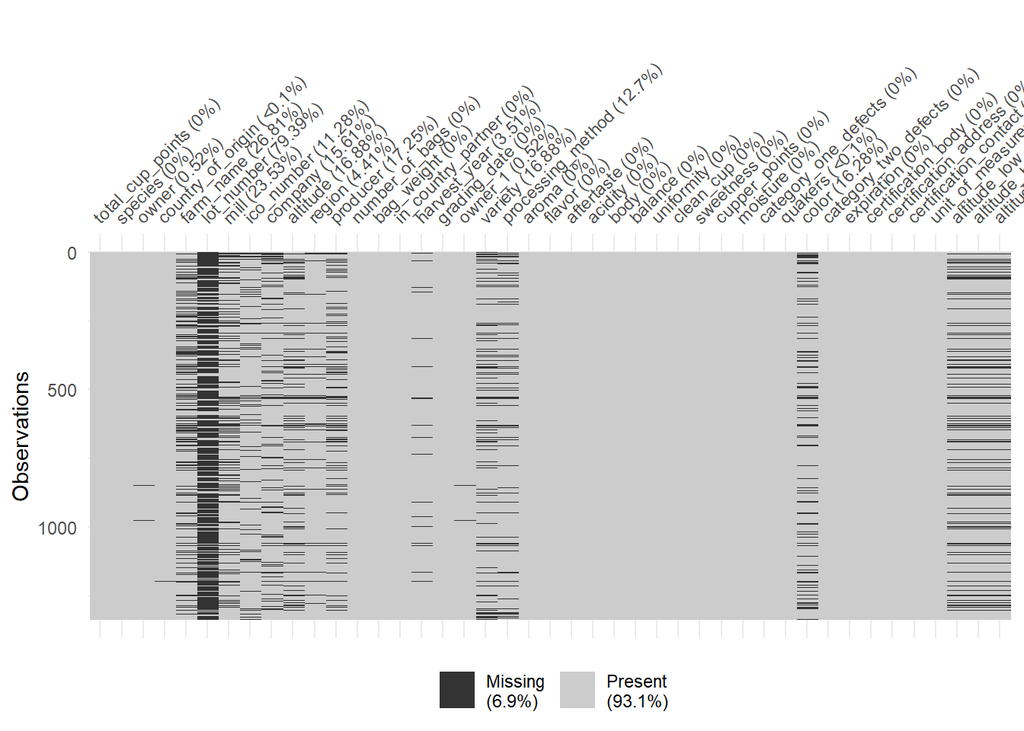

Since 6.9% of the data is missing, some filling/replacing should be made throughout the EDA.

Esslam Mumen

```
##  total_cup_points   species             owner           country_of_origin
##  Min.   : 0.00    Length:1339        Length:1339        Length:1339
##  1st Qu.:81.08    Class :character   Class :character   Class :character
##  Median :82.50    Mode  :character   Mode  :character   Mode  :character
##  Mean   :82.09
##  3rd Qu.:83.67
##  Max.   :90.58
##
##   farm_name          lot_number            mill            ico_number
##  Length:1339        Length:1339        Length:1339        Length:1339
##  Class :character   Class :character   Class :character   Class :character
##  Mode  :character   Mode  :character   Mode  :character   Mode  :character
##
##
##
##
##    company            altitude            region            producer
##  Length:1339        Length:1339        Length:1339        Length:1339
##  Class :character   Class :character   Class :character   Class :character
##  Mode  :character   Mode  :character   Mode  :character   Mode  :character
##
##
##
##
##  number_of_bags    bag_weight        in_country_partner harvest_year
##  Min.   :   0.0   Length:1339        Length:1339        Length:1339
##  1st Qu.:  14.0   Class :character   Class :character   Class :character
##  Median : 175.0   Mode  :character   Mode  :character   Mode  :character
##  Mean   : 154.2
##  3rd Qu.: 275.0
##  Max.   :1062.0
##
##  grading_date         owner_1            variety          processing_method
##  Length:1339        Length:1339        Length:1339        Length:1339
##  Class :character   Class :character   Class :character   Class :character
##  Mode  :character   Mode  :character   Mode  :character   Mode  :character
##
##
##
##
```

[output cut: 33 more lines]

```
##  Length:1339           Length:1339           Length:1339
##  Class :character      Class :character      Class :character
##  Mode  :character      Mode  :character      Mode  :character
##
##
##
##
##  altitude_low_meters altitude_high_meters altitude_mean_meters
##  Min.   :     1      Min.   :     1       Min.   :     1
##  1st Qu.:  1100      1st Qu.:  1100       1st Qu.:  1100
##  Median :  1311      Median :  1350       Median :  1311
##  Mean   :  1751      Mean   :  1799       Mean   :  1775
##  3rd Qu.:  1600      3rd Qu.:  1650       3rd Qu.:  1600
##  Max.   :190164      Max.   :190164       Max.   :190164
##  NA's   :230         NA's   :230          NA's   :230
```

```
## Rows: 1,339
## Columns: 43
## $ total_cup_points      <dbl> 90.58, 89.92, 89.75, 89.00, 88.83, 88.83, 88.75,…
## $ species               <chr> "Arabica", "Arabica", "Arabica", "Arabica", "Ara…
## $ owner                 <chr> "metad plc", "metad plc", "grounds for health ad…
## $ country_of_origin     <chr> "Ethiopia", "Ethiopia", "Guatemala", "Ethiopia",…
## $ farm_name             <chr> "metad plc", "metad plc", "san marcos barrancas …
## $ lot_number            <chr> NA, NA, NA, NA, NA, NA, NA, NA, NA, NA, NA, NA, …
## $ mill                  <chr> "metad plc", "metad plc", NA, "wolensu", "metad …
## $ ico_number            <chr> "2014/2015", "2014/2015", NA, NA, "2014/2015", N…
## $ company               <chr> "metad agricultural developmet plc", "metad agri…
## $ altitude              <chr> "1950-2200", "1950-2200", "1600 - 1800 m", "1800…
## $ region                <chr> "guji-hambela", "guji-hambela", NA, "oromia", "g…
## $ producer              <chr> "METAD PLC", "METAD PLC", NA, "Yidnekachew Dabes…
## $ number_of_bags        <dbl> 300, 300, 5, 320, 300, 100, 100, 300, 300, 50, 3…
```

[output cut: 30 more lines]

Checking the stats for the total cup points

```
##    Min. 1st Qu.  Median    Mean 3rd Qu.    Max.
##    0.00   81.08   82.50   82.09   83.67   90.58
```

Checking for extreme values “top 10 outliers” in total cup points

```
##  [1]  0.00 59.83 63.08 67.92 68.33 69.17 69.17 69.33 70.67 70.75
```

Checking for the proportion of coffee species

```
##
## Arabica Robusta
##    1311      28
```

```
##
##    Arabica    Robusta
## 0.97908887 0.02091113
```

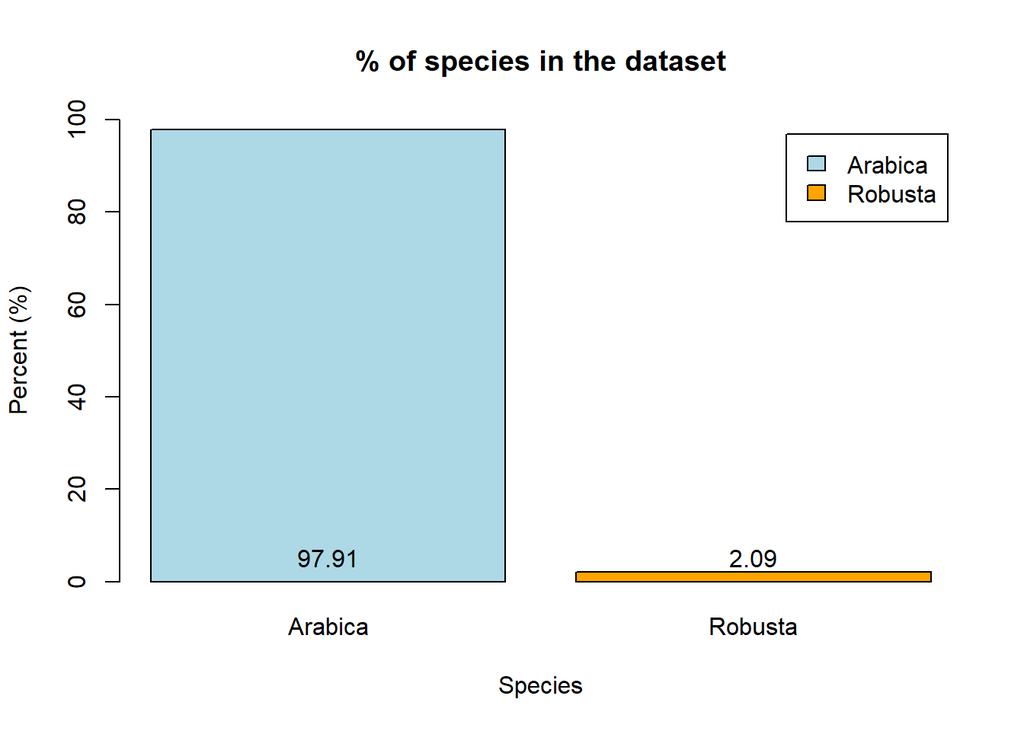

Therefore, it seems like Arabica species is much more popular than Robusta coffee

Countries Represented

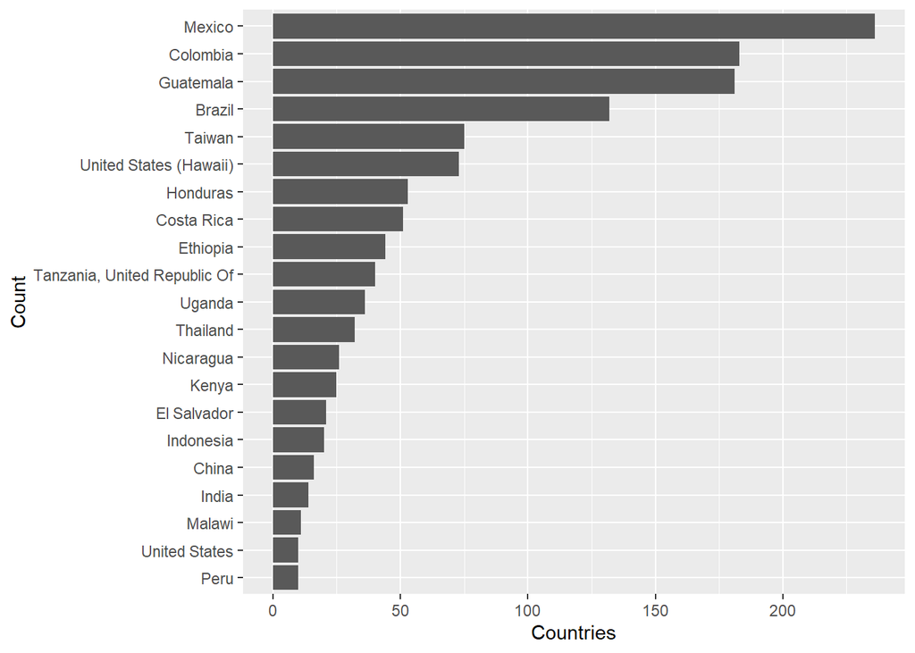

Creating the world map. This is to visualize the major producers of coffee that are included in the dataset.

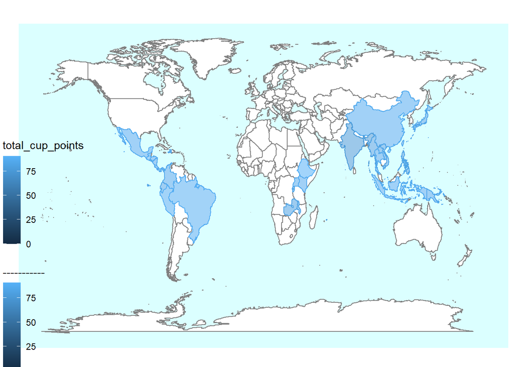

We can see here that coffee grows mainly in tropical climates

Checking for extreme values

```
##  [1] 190164 190164 110000  11000   4287   4001   3850   3845   3825   3800
```

Here, we’re going to analyze and compare the countries of origin within the scope of total cup points.

To make it more organized, let’s sort this in descending order based on the “avg” column

```
##               country_of_origin      avg      stdev   min   max range
## 24             Papua New Guinea 85.75000         NA 85.75 85.75  0.00
## 9                      Ethiopia 85.48409  2.3373542 80.00 90.58 10.58
## 15                        Japan 84.67000         NA 84.67 84.67  0.00
## 32                United States 84.43300  4.0108909 77.17 87.92 10.75
## 16                        Kenya 84.30960  1.4597331 79.83 86.25  6.42
## 23                       Panama 83.70750  2.4070504 80.75 85.83  5.08
## 31                       Uganda 83.45194  1.6135742 80.50 86.83  6.33
## 4                      Colombia 83.10656  1.4132733 72.83 86.00 13.17
## 8                   El Salvador 83.05286  1.5960299 79.67 85.58  5.91
## 3                         China 82.92750  2.3344107 78.00 87.25  9.25
## 27                       Rwanda 82.83000         NA 82.83 82.83  0.00
## 5                    Costa Rica 82.78902  2.3828833 71.75 87.17 15.42
## 30                     Thailand 82.57375  1.5463688 79.67 86.17  6.50
## 14                    Indonesia 82.56550  2.4171067 76.17 87.42 11.25
```

[output cut: 23 more lines]

```
## [1] 85.75
```

#Papa New Guinea has the highest average total cup points with a score of 85.75.

Sultan Alkadhi Checking for altitude distributions

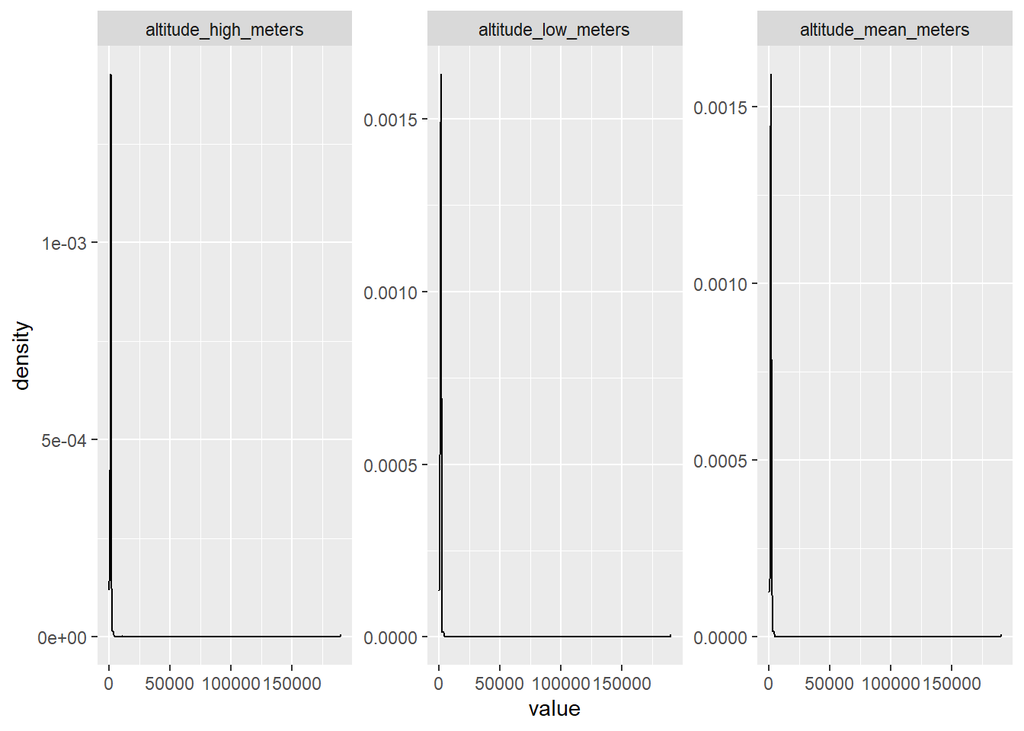

After removing erroneous values

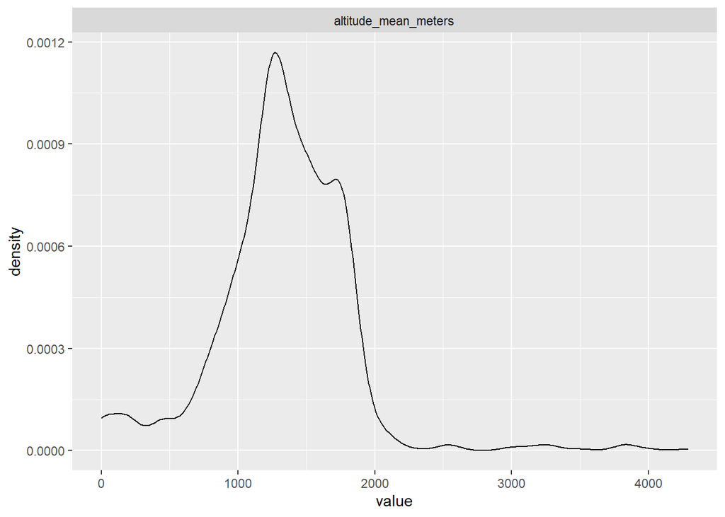

Checking the distribution of grades

[output not shown]

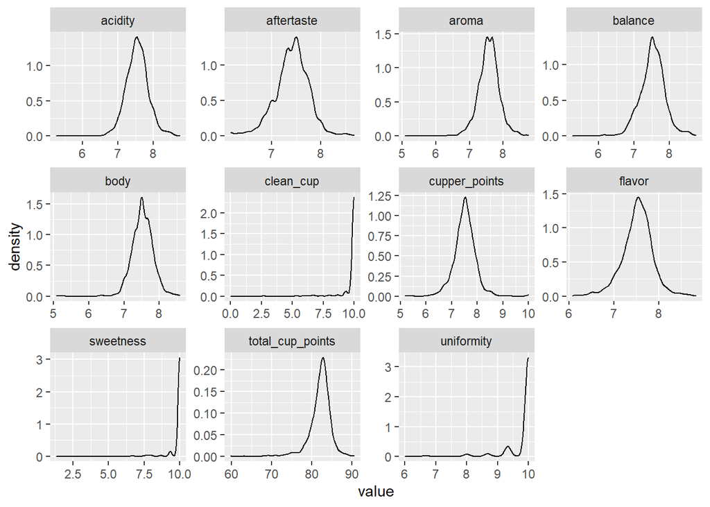

It’s easy to score high on clean cup, uniformity, and sweetness? “Uniformity refers to consistency of flavor of the different cups of the sample tasted.” “Clean Cup refers to a lack of interfering negative impressions from first ingestion to final aftertaste” “Sweetness” no longer part of the CQI scale? “Acidity is often described as”brightness” when favorable or “sour” when unfavorable. At its best, acidity contributes to a coffee’s liveliness, sweetness, and fresh- fruit character and is almost immediately experienced and evaluated when the coffee is first slurped into the mouth”

Order countries by rating and highlight altitude

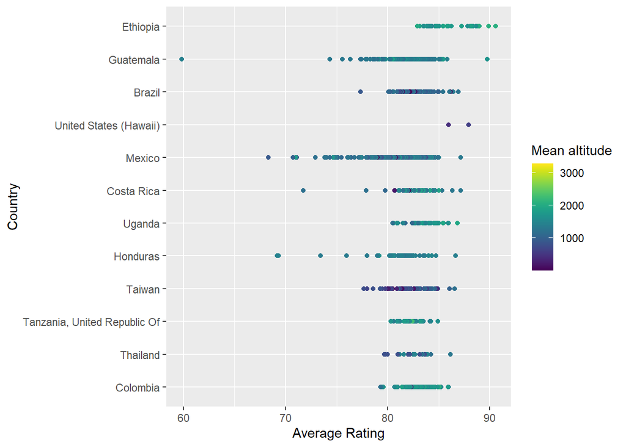

Model total score vs different grades

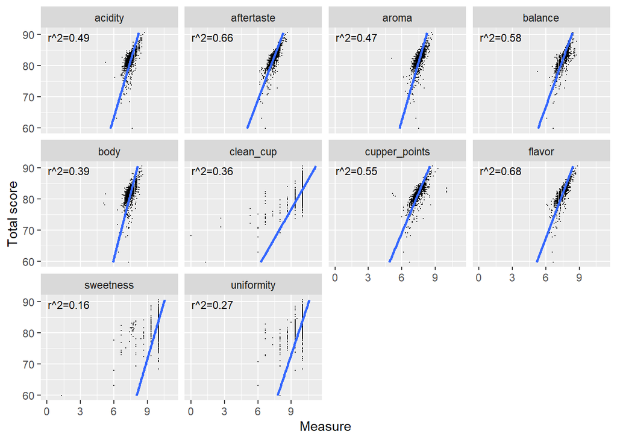

Asma AlQahtani

Relationship Between the Acidity of Coffee and the Total Cup Points

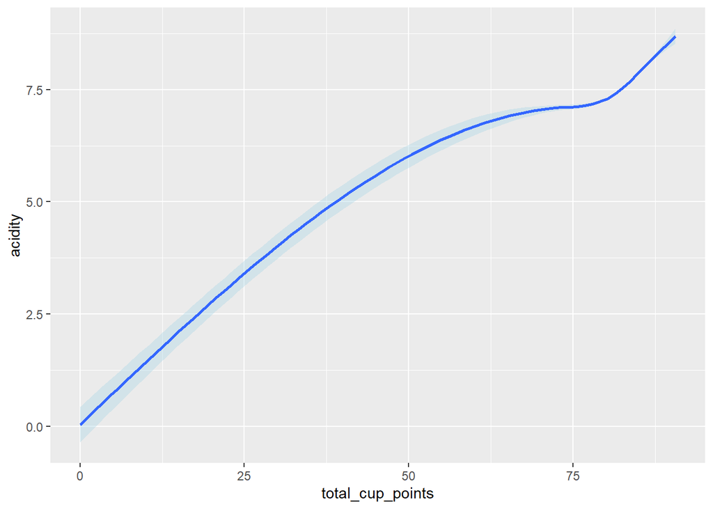

The relationship between processing method and acidity

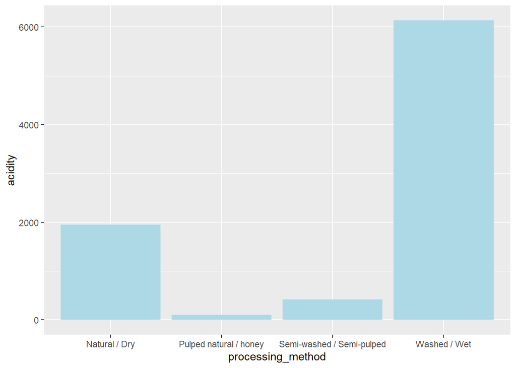

The relationship between color and acidity

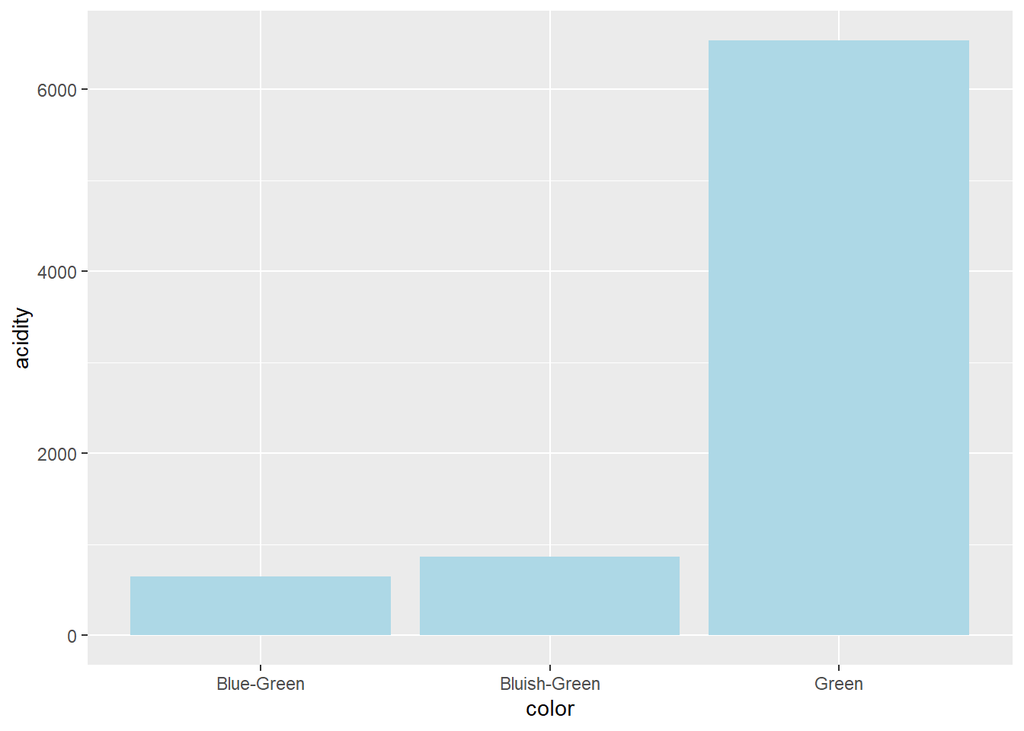

The correlation between acidity and aroma

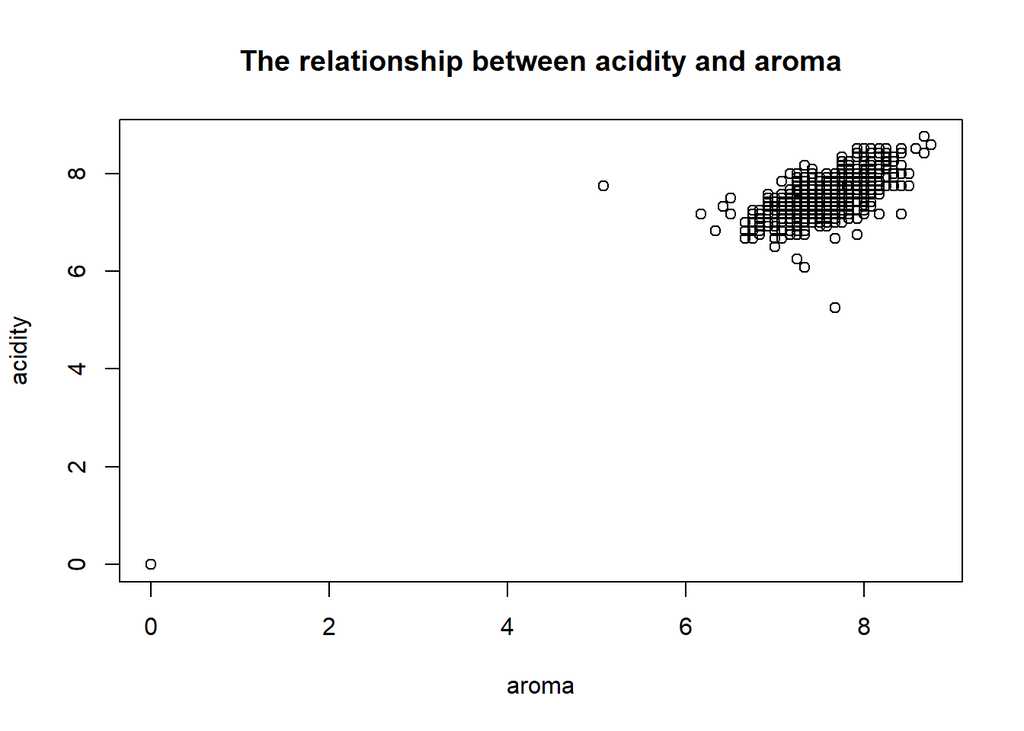

```
## [1] 0.7235822
```

The correlation between acidity and flavor

[figure not shown]

```
## [1] 0.8166883
```

The correlation between acidity and aftertaste

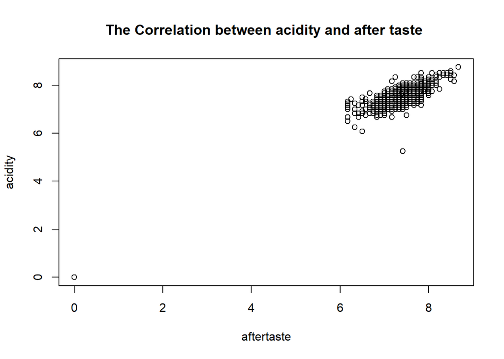

```r
plot(acidity ~ aftertaste ,data = coffee_ratings , main="The Correlation between acidity and after taste "  )
```

Raef Salem

Conclusion

Thank You!

Q&A